# NLP With Python:Semester-end Question Paper:Solutions

- [x] **Munendra Kumar**
- [x] **HOOMACL20170010**
- [x] **M.A. Computational Linguistics**
- [x] **Semester 3**
- [x] **LS176: NLP with Python**
- [x] **Course Instructor: Dr. Atreyee Sharma**

### Section 1: Question 7: Define several variables containing lists of words, e.g., phrase1, phrase2, and so on. Join them together in various combinations (using the plus operator) to form whole sentences. What is the relationship between len(phrase1 + phrase2) and len(phrase1) + len(phrase2)?

### Solution:

```python
phrase1=(['Hello','there!'])
phrase2=(['Here','are','my','details','...'])
phrase3=['Roll','No','---->','HOOMACL20170010']
phrase4=[ 'Name' '---->' 'Munendra','.']
phrase5=['Programme','---->','MA','Computational','Linguistics']
phrase6=['Course','Code','---->','LS176']
phrase7=['Course','Name','---->','NLP','with','Python']
phrase8=['Course','Instructor','---->' ,'Dr.','Atreyee','Sharma']
```

#### Joining strings while ignoring separators.

```python
''.join(phrase1+phrase2+phrase3+phrase4+phrase5+phrase6+phrase7+phrase8)
```

```
'Hellothere!Herearemydetails...RollNo---->HOOMACL20170010Name---->Munendra.Programme---->MAComputationalLinguisticsCourseCode---->LS176CourseName---->NLPwithPythonCourseInstructor---->Dr.AtreyeeSharma'
```

#### Joining strings while maintaining whitespace separator.

```python
' '.join(phrase1+phrase2+phrase3+phrase4+phrase5+phrase6+phrase7+phrase8)
```

```
'Hello there! Here are my details ... Roll No ----> HOOMACL20170010 Name---->Munendra . Programme ----> MA Computational Linguistics Course Code ----> LS176 Course Name ----> NLP with Python Course Instructor ----> Dr. Atreyee Sharma'
```

#### Joining strings while maintaining any other separator eg. ','.

```python
','.join(phrase1+phrase2+phrase3+phrase4+phrase5+phrase6+phrase7+phrase8)
```

```
'Hello,there!,Here,are,my,details,...,Roll,No,---->,HOOMACL20170010,Name---->Munendra,.,Programme,---->,MA,Computational,Linguistics,Course,Code,---->,LS176,Course,Name,---->,NLP,with,Python,Course,Instructor,---->,Dr.,Atreyee,Sharma'
```

```python
#### Calculating length
```

```python
len(phrase1)+len(phrase2)+len(phrase3)+len(phrase4)+len(phrase5)+len(phrase6)+len(phrase7)+len(phrase8)
 #calculating length of the phrases
```

```
34
```

```python
len(phrase1+phrase2+phrase3+phrase4+phrase5+phrase6+phrase7+phrase8) #calculating length of the phrases
```

```
34
```

#### The Function len(phrase1)+len(phrase2)+len(phrase3)... is redundant and repetitive instead function len(phrase1+phrase2+phrase3) is more convenient. It is like calling 'len' function just once instead of calling it 'n' times.

### Section 2: Question 7: Write a function that finds the 50 most frequently occurring words of a text that are not stopwords.

```python
nltk.corpus.gutenberg.fileids() # accessing gutenberg corpus
```

```
['austen-emma.txt',
 'austen-persuasion.txt',
 'austen-sense.txt',
 'bible-kjv.txt',
 'blake-poems.txt',
 'bryant-stories.txt',
 'burgess-busterbrown.txt',
 'carroll-alice.txt',
 'chesterton-ball.txt',
 'chesterton-brown.txt',
 'chesterton-thursday.txt',
 'edgeworth-parents.txt',
 'melville-moby_dick.txt',
 'milton-paradise.txt',
 'shakespeare-caesar.txt',
 'shakespeare-hamlet.txt',
 'shakespeare-macbeth.txt',
 'whitman-leaves.txt']
```

```python
import nltk
from nltk.corpus import gutenberg #importing dependencies
from nltk.corpus import stopwords
from nltk.tokenize import sent_tokenize, word_tokenize
```

```python
text=nltk.data.load('/home/munendra/nltk_data/corpora/gutenberg/whitman-leaves.txt') #importing text from local disk
```

```python
print(text[:100]) # printing range [0-100] of the corpus
```

```
[Leaves of Grass by Walt Whitman 1855]


Come, said my soul,
Such verses for my Body let us write, (
```

```python
tokens = word_tokenize(text)
type(tokens)
len(tokens)
```

```
149203
```

```python
print(tokens[:10])
```

```
['[', 'Leaves', 'of', 'Grass', 'by', 'Walt', 'Whitman', '1855', ']', 'Come']
```

```python
import string
tokens = [w.lower() for w in tokens]
table = str.maketrans('', '', string.punctuation)
stripped = [w.translate(table) for w in tokens]
from nltk.corpus import stopwords
words = [word for word in tokens if word.isalpha()]
print(words[:10])
stop_words = stopwords.words('english')
my_stopwords=(['i','the','and','to','thy','you','in','of','thee','thou','us','these','this'])
words = [w for w in words if not w in stop_words]
words = [w for w in words if not w in my_stopwords]
print(words[:10])

import string
table = str.maketrans('', '', string.punctuation)
stripped = [w.translate(table) for w in words]
```

```
['leaves', 'of', 'grass', 'by', 'walt', 'whitman', 'come', 'said', 'my', 'soul']
['leaves', 'grass', 'walt', 'whitman', 'come', 'said', 'soul', 'verses', 'body', 'let']
```

```python
import matplotlib.pyplot as plt # importing dependencies
import pandas as pd
from collections import Counter # importing counter
Counter = Counter(words)
most_occur = Counter.most_common()
print(most_occur[:50]) # Printing 50 most occuring words
```

[output not shown]

### Section 3: Question 3: Take any string and perform all the operations and justify your answers by giving reasons? (check section 3.2 from the book)

#### First string input and calling string

```python
str1= 'Record 75% voting in Madhya Pradesh.'
print (str1) #printing first string
```

```
Record 75% voting in Madhya Pradesh.
```

#### Second string input and calling string

```python
str2="A record 75 per cent voter turnout for the Madhya Pradesh's state Assembly polls that was marred by complaints of faulty EVMs with the BJP looking for a fourth straight term in a tough battle with a resurgent Congress which is eyeing a comeback after 15 years."
print (str2) # printing second string
```

```
A record 75 per cent voter turnout for the Madhya Pradesh's state Assembly polls that was marred by complaints of faulty EVMs with the BJP looking for a fourth straight term in a tough battle with a resurgent Congress which is eyeing a comeback after 15 years.
```

#### Escaping a character i.e. intendending

```python
str2="A record 75 per cent voter turnout for the Madhya Pradesh\'s state Assembly polls that was marred by complaints of faulty EVMs with the BJP looking for a fourth straight term in a tough battle with a resurgent Congress which is eyeing a comeback after 15 years."
print (str2) # printing a escaped character ''s' as in Madhya Pradesh's
```

```
A record 75 per cent voter turnout for the Madhya Pradesh's state Assembly polls that was marred by complaints of faulty EVMs with the BJP looking for a fourth straight term in a tough battle with a resurgent Congress which is eyeing a comeback after 15 years.
```

```python
str2="A record 75 per cent voter turnout for the Madhya Pradesh's "\
"state Assembly polls that was marred by complaints "\
"of faulty EVMs with the BJP looking for a fourth "\
"straight term in a tough battle with a resurgent Congress "\
"which is eyeing a comeback after 15 years."
print (str2) # printing string in new line to avoid the problem above where whole string is in one line.
             # but this doesn't give the output in the new line.
```

```
A record 75 per cent voter turnout for the Madhya Pradesh's state Assembly polls that was marred by complaints of faulty EVMs with the BJP looking for a fourth straight term in a tough battle with a resurgent Congress which is eyeing a comeback after 15 years.
```

```python
str2="""A record 75 per cent voter turnout for the Madhya Pradesh's
state Assembly polls that was marred by complaints
of faulty EVMs with the BJP looking for a fourth
straight term in a tough battle with a resurgent Congress
which is eyeing a comeback after 15 years."""
print (str2) # printing string in the user formatted new line using ('''or """) triple quoted strings
```

```
A record 75 per cent voter turnout for the Madhya Pradesh's
state Assembly polls that was marred by complaints
of faulty EVMs with the BJP looking for a fourth
straight term in a tough battle with a resurgent Congress
which is eyeing a comeback after 15 years.
```

```python
str2='''A record 75 per cent voter turnout for the Madhya Pradesh's
state Assembly polls that was marred by complaints
of faulty EVMs with the BJP looking for a fourth
straight term in a tough battle with a resurgent Congress
which is eyeing a comeback after 15 years.'''
print (str2*2+str1*5) # printing combination of str2 twice and combining str1 with str2 five times.
```

```
A record 75 per cent voter turnout for the Madhya Pradesh's
state Assembly polls that was marred by complaints
of faulty EVMs with the BJP looking for a fourth
straight term in a tough battle with a resurgent Congress
which is eyeing a comeback after 15 years.A record 75 per cent voter turnout for the Madhya Pradesh's
state Assembly polls that was marred by complaints
of faulty EVMs with the BJP looking for a fourth
straight term in a tough battle with a resurgent Congress
which is eyeing a comeback after 15 years.Record 75% voting in Madhya Pradesh.Record 75% voting in Madhya Pradesh.Record 75% voting in Madhya Pradesh.Record 75% voting in Madhya Pradesh.Record 75% voting in Madhya Pradesh.
```

```python
print(str1+str2) # printing combination of str1 and str2
```

```
Record 75% voting in Madhya Pradesh.A record 75 per cent voter turnout for the Madhya Pradesh's
state Assembly polls that was marred by complaints
of faulty EVMs with the BJP looking for a fourth
straight term in a tough battle with a resurgent Congress
which is eyeing a comeback after 15 years.
```

```
R
e
c
o
r
d
Re
Record 75%
dict_keys(['r', 'e', 'c', 'o', 'd', 'v', 't', 'i', 'n', 'g', 'm', 'a', 'h', 'y', 'p', 's'])
```

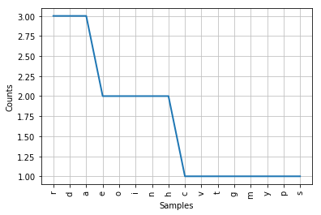

```python
# Printing individual characters
print(str1[0]) # printing character from a certain index '0' in a string
print(str1[1])# printing character from a certain index '1' in a string
print(str1[2])# printing character from a certain index '2' in a string
print(str1[3])# printing character from a certain index '3' in a string
print(str1[4])# printing character from a certain index '4' in a string
print(str1[5])# printing character from a certain index '5' in a string

# Printing a range of characters
print(str1[0:2]) # printing range '0-2' characters in a string
print(str1[0:10]) # printing range '0-10' characters in a string


fdist = nltk.FreqDist(ch.lower() for ch in str1 if ch.isalpha()) #counter for characters in a string
print (fdist.keys()) # printing most frequent characters from a string
fdist.plot() # visualising most frequent characters from string
```

```python
len (str1)
```

```
36
```

```python
print(str1[-36:-1])
```

```
Record 75% voting in Madhya Pradesh
```

```python
for char in str1:
    print(char)
```

```
R
e
c
o
r
d

7
5
%

v
o
t
i
n
g

i
n

M
a
d
h
y
a

P
r
a
d
e
s
h
.
```

```python
str1.find('e') # finds index of first instance of string 'e' in str1
```

```
1
```

```python
str1.rfind('e') # finds index of last instance of string 'e' in str1
```

```
32
```

```python
str1.index('e') # finds index of first instance of string 'e' in str1
```

```
1
```

```python
str1.rindex('e') # finds index of last instance of string 'e' in str1
```

```
32
```

```python
str4=''
for i in str1 :
    str4=str1.split() #storing string as a list
```

```python
print (str4) # printing list
```

```
['Record', '75%', 'voting', 'in', 'Madhya', 'Pradesh.']
```

```python
print(str2.splitlines()) # spliting lines
```

```
["A record 75 per cent voter turnout for the Madhya Pradesh's", 'state Assembly polls that was marred by complaints', 'of faulty EVMs with the BJP looking for a fourth', 'straight term in a tough battle with a resurgent Congress', 'which is eyeing a comeback after 15 years.']
```

```python
print(str2.lower())  # printing string in lower case
```

```
a record 75 per cent voter turnout for the madhya pradesh's
state assembly polls that was marred by complaints
of faulty evms with the bjp looking for a fourth
straight term in a tough battle with a resurgent congress
which is eyeing a comeback after 15 years.
```

```python
print(str2.upper())  # printing string in upper case
```

```
A RECORD 75 PER CENT VOTER TURNOUT FOR THE MADHYA PRADESH'S
STATE ASSEMBLY POLLS THAT WAS MARRED BY COMPLAINTS
OF FAULTY EVMS WITH THE BJP LOOKING FOR A FOURTH
STRAIGHT TERM IN A TOUGH BATTLE WITH A RESURGENT CONGRESS
WHICH IS EYEING A COMEBACK AFTER 15 YEARS.
```

```python
print(str2.title()) # printing string in title case
```

```
A Record 75 Per Cent Voter Turnout For The Madhya Pradesh'S
State Assembly Polls That Was Marred By Complaints
Of Faulty Evms With The Bjp Looking For A Fourth
Straight Term In A Tough Battle With A Resurgent Congress
Which Is Eyeing A Comeback After 15 Years.
```

```python
print(str2.strip()) #removing extra spaces if any using strip function
```

```
A record 75 per cent voter turnout for the Madhya Pradesh's
state Assembly polls that was marred by complaints
of faulty EVMs with the BJP looking for a fourth
straight term in a tough battle with a resurgent Congress
which is eyeing a comeback after 15 years.
```

```python
print(str2.replace('record','huge record of')) # using replace function to replace 'record' with 'huge record of'
```

```
A huge record of 75 per cent voter turnout for the Madhya Pradesh's
state Assembly polls that was marred by complaints
of faulty EVMs with the BJP looking for a fourth
straight term in a tough battle with a resurgent Congress
which is eyeing a comeback after 15 years.
```

#### Difference between strings and Lists

```python
print (str1) # this is a string
print (str4) # this is a list
```

```
Record 75% voting in Madhya Pradesh.
['Record', '75%', 'voting', 'in', 'Madhya', 'Pradesh.']
```

```python
print(str1[0]) # at index 0 string output
print(str4[0]) # at index 0 list output
```

```
R
Record
```

```python
print(str1[:6]) # from range 0-6 string output
print(str4[:6]) # from range 0-6 list output
```

```
Record
['Record', '75%', 'voting', 'in', 'Madhya', 'Pradesh.']
```

```python
print(len(str1)) # length of the string
print(len(str4)) # length of the list
```

```
36
6
```

#### So it is clear from above that strings store every single character including whitespaces as a string. While lists store every word excluding whitespaces